# Measuring the impact of pathologic features of penile squamous cell carcinomas in PD-L1 expression

Alcides Chaux

```r
library(readr)
library(ggplot2)
library(dplyr)
library(tidyr)
library(knitr)
library(forcats)

theme_set(theme_classic())
opts_chunk$set(message = FALSE, warning = FALSE)
```

# INTRODUCTION

Penile squamous cell carcinoma (SCC) is a rare tumor for which few effective treatment options are available for advanced disease. Considering the significant morbidity of the standard treatment, identifying novel molecular and immunotherapeutic targets is actively sought. Programmed death-ligand 1 (PD-L1) is a coinhibitory molecule that impairs the T-cell response by down-regulating T-cell proliferation and cytokine production. Tumor cells often up-regulate PD-L1 and thereby evade the host immune system. Recently, immune-checkpoint inhibitors have been proven effective against several tumor types, but data on PD-L1 expression in penile SCC is scant with only few reports from low-incidence areas (1–5). In this study, we evaluate PD-L1 expression in a large dataset of patients with penile SCC from a high-incidence area.

```r
# Data
df <- read_csv('PFCK_PRY_DF.csv')
glimpse(df)
```

```
## Rows: 528
## Columns: 23
## $ x                     <dbl> 1, 2, 3, 5, 6, 7, 9, 10, 11, 13, 14, 15, 5, 6...
## $ y                     <dbl> 1, 1, 1, 1, 1, 1, 1, 1, 1, 1, 1, 1, 2, 2, 2, ...
## $ sp                    <chr> "S06-01500", "S06-01500", "S06-01500", "S03-0...
## $ tma                   <dbl> 852, 852, 852, 852, 852, 852, 852, 852, 852, ...
## $ subtype               <chr> "Warty", "Warty", "Warty", "Warty-Basaloid", ...
## $ grade                 <chr> "Grade 3", "Grade 3", "Grade 3", "Grade 3", "...
## $ pdl1_tumor            <dbl> 1, 30, 5, 2, 5, 3, 0, 0, 0, 50, 95, 35, 3, 0,...
## $ pdl1_tumor_location   <chr> "Cytoplasmic/Membraneous", "Cytoplasmic/Membr...
## $ pdl1_tumor_h          <dbl> 1, 35, 5, 2, 5, 3, 0, 0, 0, 55, 135, 40, 3, 0...
## $ pdl1_lymph            <dbl> 5, 0, 5, 6, 2, 1, 10, 5, 2, 10, 5, 15, 2, 0, ...
## $ host_response         <chr> "Lymphoid aggregates", "Rare inflammatory cel...
## $ foxp3_lymph_tumor     <dbl> 0, 0, 3, 11, 6, 4, 1, 2, 2, 43, 40, 47, 2, 1,...
## $ foxp3_lymph_stroma    <dbl> 8, 2, 0, 32, 50, 40, 65, 70, 66, 16, 74, 80, ...
## $ foxp3_lymph_intensity <chr> "Strong staining", "Strong staining", "No sta...
## $ foxp3_tumor           <dbl> 20, 7, 5, 0, 0, 0, 0, 0, 0, 0, 0, 0, 0, 1, 1,...
## $ foxp3_tumor_intensity <chr> "Moderate staining", "Weak staining", "Weak s...
## $ cd8_tumor             <dbl> 0, 0, 0, 37, 24, 13, 0, 0, 0, 32, 13, 28, 3, ...
## $ cd8ki67_tumor         <dbl> 0, 0, 0, 0, 0, 0, 0, 0, 0, 0, 0, 0, 0, 0, 0, ...
## $ cd8_stroma            <dbl> 15, 0, 0, 33, 50, 76, 39, 7, 22, 0, 30, 29, 9...
## $ cd8ki67_stroma        <dbl> 0, 0, 0, 0, 0, 0, 0, 0, 0, 0, 0, 0, 0, 0, 0, ...
## $ ki67_tumor            <dbl> 5, 1, 1, 1, 1, 1, 1, 1, 1, 0, 0, 0, 0, 0, 0, ...
## $ cd8foxp3_tumor        <chr> "CD8 <= FOXP3", "CD8 <= FOXP3", "CD8 <= FOXP3...
## $ cd8foxp3_stroma       <chr> "CD8 > FOXP3", "CD8 <= FOXP3", "CD8 <= FOXP3"...
```

# RESULTS

## Pathologic features

### Histologic subtype

```r
tbl <- df %>%
  group_by(subtype) %>%
  summarize(n = n_distinct(sp)) %>%
  arrange(desc(n))

print(tbl)
```

```
## # A tibble: 7 x 2
##   subtype            n
##   <chr>          <int>
## 1 Usual             45
## 2 Warty-Basaloid    24
## 3 Warty             16
## 4 Basaloid          11
## 5 Papillary          9
## 6 Verrucous          2
## 7 Sarcomatoid        1
```

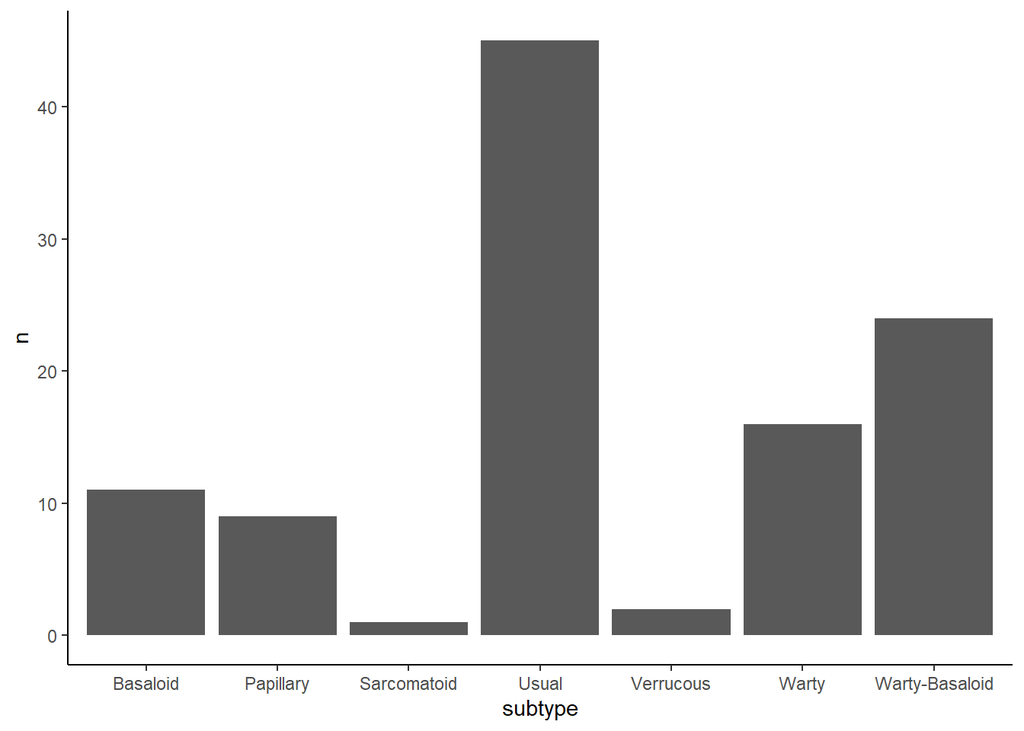

```r
ggplot(tbl, aes(x = subtype, y = n)) +
  geom_col()
```

The most common subtype, as expected was usual squamous cell carcinoma (45 cases), followed by warty-basaloid (24 cases), warty (16 cases) and basaloid (11 cases) carcinomas. Other subtypes included papillary (9 cases), verrucous (2 cases) and sarcomatoid (1 case) carcinomas.

### Histologic grade

```r
df <- df %>%
  mutate(
    grade = fct_recode(grade, Grade_1 = 'Grade 1', Grade_2 = 'Grade 2', Grade_3 = 'Grade 3'),
    grade = factor(grade, levels = c('Grade_1','Grade_2', 'Grade_3'), ordered = TRUE)
  )

tbl <- df %>%
  count(grade) %>%
  drop_na()

print(tbl)
```

```
## # A tibble: 3 x 2
##   grade       n
##   <ord>   <int>
## 1 Grade_1    51
## 2 Grade_2   191
## 3 Grade_3   262
```

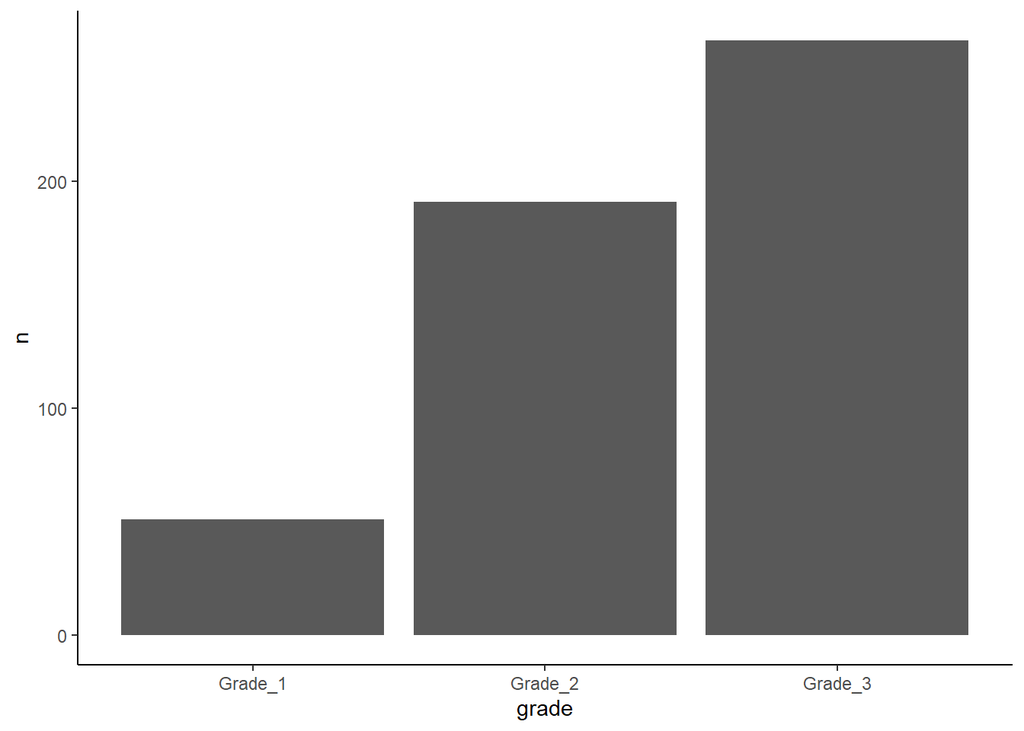

```r
ggplot(tbl, aes(x = grade, y = n)) +
  geom_col()
```

Grade 1 was observed in 51 spots, grade 2 was observed in 191 spots, and grade 3 was observed in 262 spots. This over-representation of grade 3 tumors is expected considering the geographical location of the patients. Tumors in patients from geographic areas of high incidence of penile cancer tend to be larger and of higher grade.

```r
df <- df %>%
  mutate(
    host_response = fct_recode(host_response,
      'No' = 'No inflammatory cells',
      'Mild' = 'Rare inflammatory cells',
      'Moderate' = 'Lymphoid aggregates',
      'Intense' = 'Intense inflammation'
    ),
    host_response = factor(
      host_response,
      levels = c('No', 'Mild', 'Moderate', 'Intense'),
      ordered = TRUE
    )
  )

tbl <- df %>%
  count(host_response) %>%
  drop_na()

print(tbl)
```

```
## # A tibble: 4 x 2
##   host_response     n
##   <ord>         <int>
## 1 No                4
## 2 Mild             96
## 3 Moderate        154
## 4 Intense         250
```

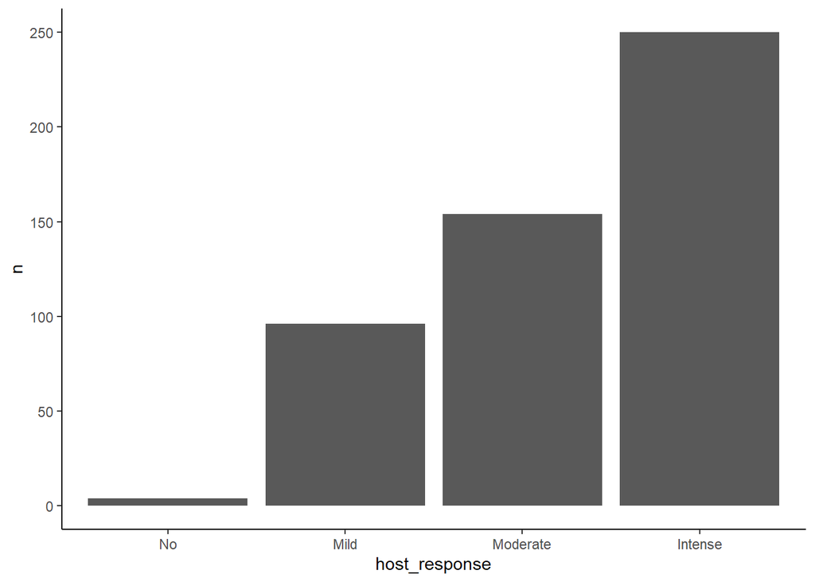

```r
ggplot(tbl, aes(x = host_response, y = n)) +
  geom_col()
```

### Host response

In most cases, a host response was observed. In only 4 spots, no inflammatory cells were seen. In the remaining cases, mild inflammation was seen in 96 spots, moderate inflammation in 154 spots, and intense inflammation in 250 spots.

```r
tbl <- df %>%
  group_by(grade, subtype) %>%
  count() %>%
  drop_na()

tbl %>%
  pivot_wider(names_from = grade, values_from = n) %>%
  replace_na(list(Grade_1 = 0, Grade_2 = 0, Grade_3 = 0))
```

```
## # A tibble: 7 x 4
## # Groups:   subtype [7]
##   subtype        Grade_1 Grade_2 Grade_3
##   <chr>            <dbl>   <dbl>   <dbl>
## 1 Papillary           13      26       1
## 2 Usual               34     103      57
## 3 Verrucous            3       4       0
## 4 Warty                1      30      45
## 5 Warty-Basaloid       0      28      92
## 6 Basaloid             0       0      64
## 7 Sarcomatoid          0       0       3
```

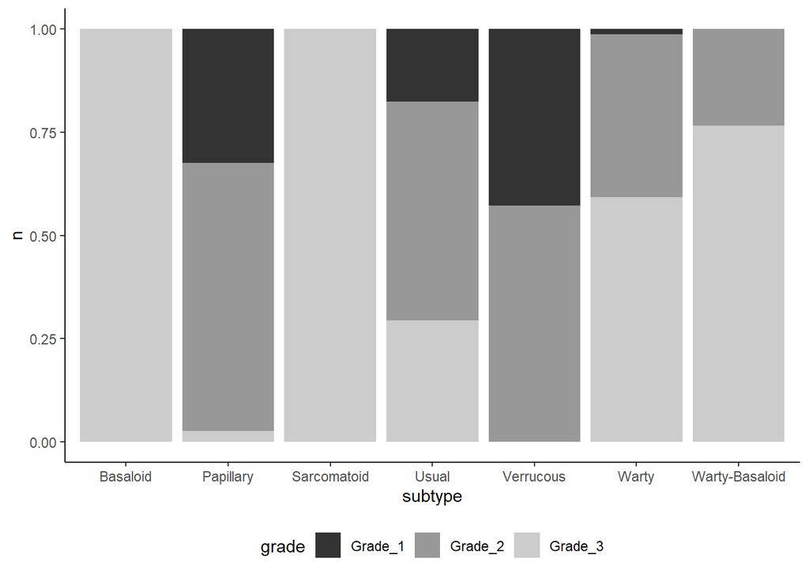

```r
ggplot(tbl, aes(x = subtype, y = n, fill = grade)) +
  geom_col(position = 'fill') +
  scale_fill_grey() +
  theme(legend.position = 'bottom')
```

```r
chisq.test(df$grade, df$subtype)
```

```
##
##  Pearson's Chi-squared test
##
## data:  df$grade and df$subtype
## X-squared = 200.98, df = 12, p-value < 2.2e-16
```

### Histologic subtype by histologic grade

Basaloid and sarcomatoid carcinomas were entirely composed of grade 3 areas. Warty-basaloid and warty carcinomas were composed of predominantly grade 2 and grade 3 areas, while papillary and verrucous carcinoma were composed predominantly of grade 1 and grade 2 areas. Usual squamous cell carcinoma showed the heterogeneous aspect that it most common, with a mixture of histologic grades, predominantly grade 2 areas. This distribution pattern was totally consistent with the typical morphology of penile squamous cell carcinomas regarding histologic subtypes and grades. The association between histologic grade and histologic subtype was statistically significant (P<0.00001).

```r
tbl <- df %>%
  group_by(host_response, subtype) %>%
  count() %>%
  drop_na()

tbl %>%
  pivot_wider(names_from = host_response, values_from = n) %>%
  replace_na(list(No = 0, Mild = 0, Moderate = 0))
```

```
## # A tibble: 7 x 5
## # Groups:   subtype [7]
##   subtype           No  Mild Moderate Intense
##   <chr>          <dbl> <dbl>    <dbl>   <int>
## 1 Basaloid           1    12       17      34
## 2 Papillary          1     7       14      18
## 3 Warty              1    14       21      41
## 4 Warty-Basaloid     1    22       41      57
## 5 Usual              0    36       61      95
## 6 Verrucous          0     5        0       2
## 7 Sarcomatoid        0     0        0       3
```

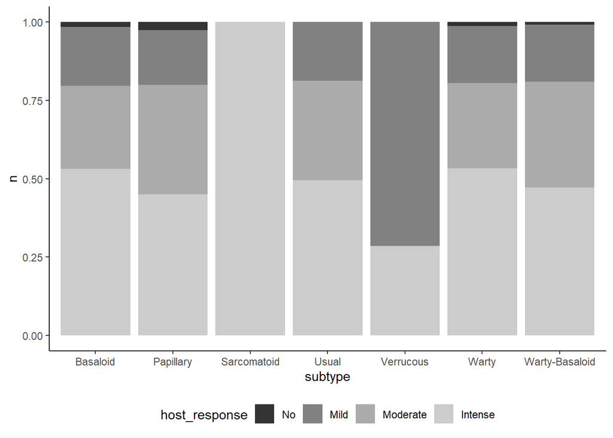

```r
ggplot(tbl, aes(x = subtype, y = n, fill = host_response)) +
  geom_col(position = 'fill') +
  scale_fill_grey() +
  theme(legend.position = 'bottom')
```

```r
chisq.test(df$host_response, df$subtype)
```

```
##
##  Pearson's Chi-squared test
##
## data:  df$host_response and df$subtype
## X-squared = 21.892, df = 18, p-value = 0.2368
```

### Histologic subtype by host response

```r
tbl <- df %>%
  group_by(host_response, grade) %>%
  count() %>%
  drop_na()

tbl %>%
  pivot_wider(names_from = grade, values_from = n)
```

```
## # A tibble: 4 x 4
## # Groups:   host_response [4]
##   host_response Grade_1 Grade_2 Grade_3
##   <ord>           <int>   <int>   <int>
## 1 No                  1       1       2
## 2 Mild               15      36      45
## 3 Moderate           18      59      74
## 4 Intense            17      93     137
```

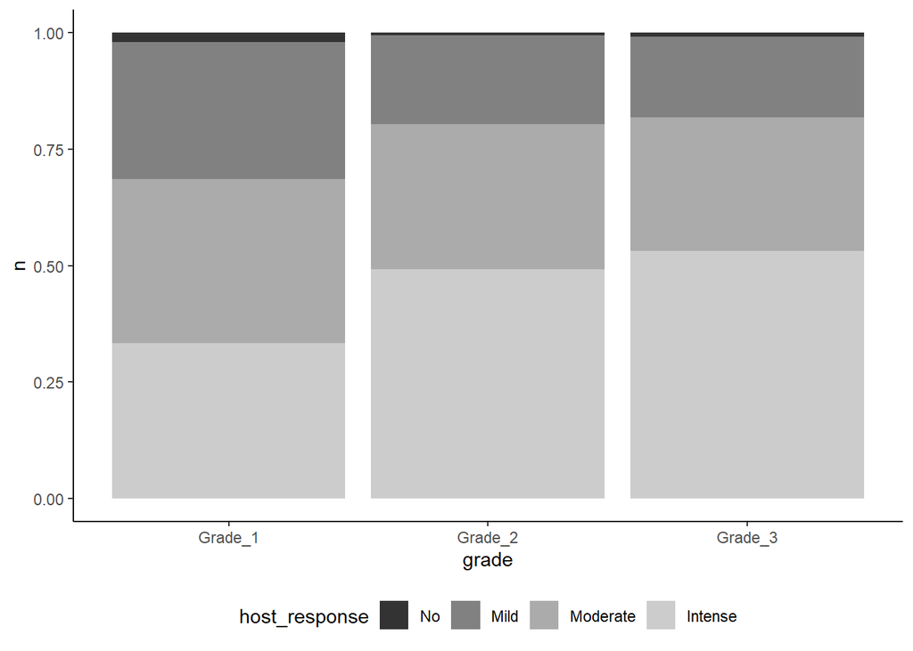

```r
ggplot(tbl, aes(x = grade, y = n, fill = host_response)) +
  geom_col(position = 'fill') +
  scale_fill_grey() +
  theme(legend.position = 'bottom')
```

```r
chisq.test(df$host_response, df$grade)
```

```
##
##  Pearson's Chi-squared test
##
## data:  df$host_response and df$grade
## X-squared = 8.2622, df = 6, p-value = 0.2195
```

### Histologic grade by host response

Intense inflammation predominated in grade 2 and grade 3 tumors, followed by moderate inflammation and mild inflammation. In grade 1 tumors, proportions of mild, moderate and intense inflammation were similar. These differences were not statistically significant (P=0.22), indicating no association between histologic grade and host response.

## PDL1 expression

### Tumor cells, percentage

```r
spots <- length(df$pdl1_tumor) - sum(is.na(df$pdl1_tumor))
print(spots)
```

```
## [1] 504
```

```r
summary(df$pdl1_tumor)
```

```
##    Min. 1st Qu.  Median    Mean 3rd Qu.    Max.    NA's
##    0.00    0.00    5.00   25.58   40.00  100.00      24
```

```r
sd(df$pdl1_tumor, na.rm = TRUE)
```

```
## [1] 34.41787
```

```r
IQR(df$pdl1_tumor, na.rm = TRUE)
```

```
## [1] 40
```

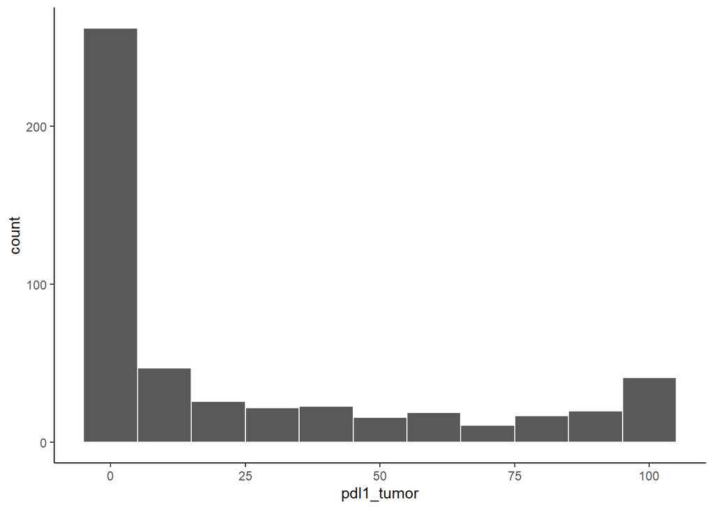

```r
ggplot(df, aes(x = pdl1_tumor)) +
  geom_histogram(binwidth = 10, color = 'white')
```

PD-L1 expression in tumor cells was evaluable in 504 spots. In tumor cells, mean expression was 26%, with a standard deviation of 34%. Median expression was 5%, with an interquartile range of 40%. The minimum value was 0% and the maximum value was 100%. PD-L1 expression in tumor cells showed a marked right-skewed distribution, suggesting that most values were very low.

```r
df %>%
  mutate(pdl1_tumor_pos = ifelse(pdl1_tumor >= 1, "PD-L1 positive", "PD-L1 negative")) %>%
  group_by(pdl1_tumor_pos) %>%
  count() %>%
  drop_na() %>%
  mutate(percent = n/spots * 100)
```

```
## # A tibble: 2 x 3
## # Groups:   pdl1_tumor_pos [2]
##   pdl1_tumor_pos     n percent
##   <chr>          <int>   <dbl>
## 1 PD-L1 negative   173    34.3
## 2 PD-L1 positive   331    65.7
```

Considering >= 1% as the threshold for PD-L1 positivity, most spots (66%) were positive, compared to negative spots (34%).

```r
df %>%
  group_by(pdl1_tumor_location) %>%
  count() %>%
  drop_na() %>%
  mutate(percent = n/331 * 100)
```

```
## # A tibble: 2 x 3
## # Groups:   pdl1_tumor_location [2]
##   pdl1_tumor_location         n percent
##   <chr>                   <int>   <dbl>
## 1 Cytoplasmic/Membraneous   250    75.5
## 2 Cytplasmic                 81    24.5
```

Two patterns of PD-L1 expression were observed in tumor cells. The predominant pattern was cytoplasmic and membranous (250 spots, 76%) with only cytoplasmic expression in the remaining cases (81 spots, 24%).

### Tumor cells, H-score

```r
spots <- length(df$pdl1_tumor_h) - sum(is.na(df$pdl1_tumor_h))
print(spots)
```

```
## [1] 504
```

```r
summary(df$pdl1_tumor_h)
```

```
##    Min. 1st Qu.  Median    Mean 3rd Qu.    Max.    NA's
##    0.00    0.00    5.00   36.37   50.00  300.00      24
```

```r
sd(df$pdl1_tumor_h, na.rm = TRUE)
```

```
## [1] 59.53553
```

```r
IQR(df$pdl1_tumor_h, na.rm = TRUE)
```

```
## [1] 50
```

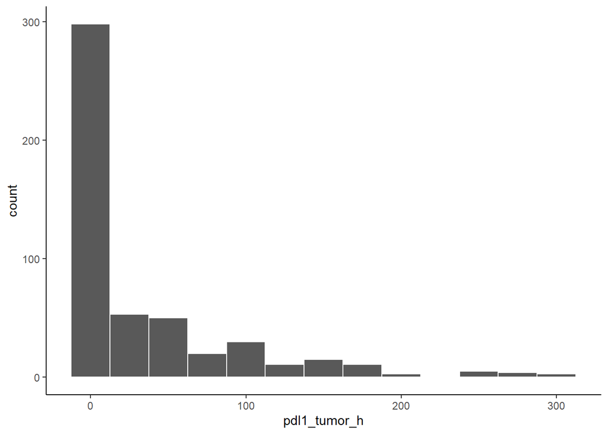

```r
ggplot(df, aes(x = pdl1_tumor_h)) +
  geom_histogram(binwidth = 25, color = 'white')
```

Regarding H-scores, in tumor cells PD-L1 had a mean H-score of 36 with a standard deviation of 60. Median H-score was 5 and interquartile range was 50. The minimum and maximum values were 0 and 300, respectively. The distribution of H-scores showed the same right-skewed shape than with percentages, as expected.

### Intratumoral lymphocytes, count

```r
spots <- length(df$pdl1_lymph) - sum(is.na(df$pdl1_lymph))
print(spots)
```

```
## [1] 497
```

```r
summary(df$pdl1_lymph)
```

```
##    Min. 1st Qu.  Median    Mean 3rd Qu.    Max.    NA's
##   0.000   1.000   5.000   7.402  10.000  70.000      31
```

```r
sd(df$pdl1_lymph,na.rm = TRUE)
```

```
## [1] 10.40098
```

```r
IQR(df$pdl1_lymph,na.rm = TRUE)
```

```
## [1] 9
```

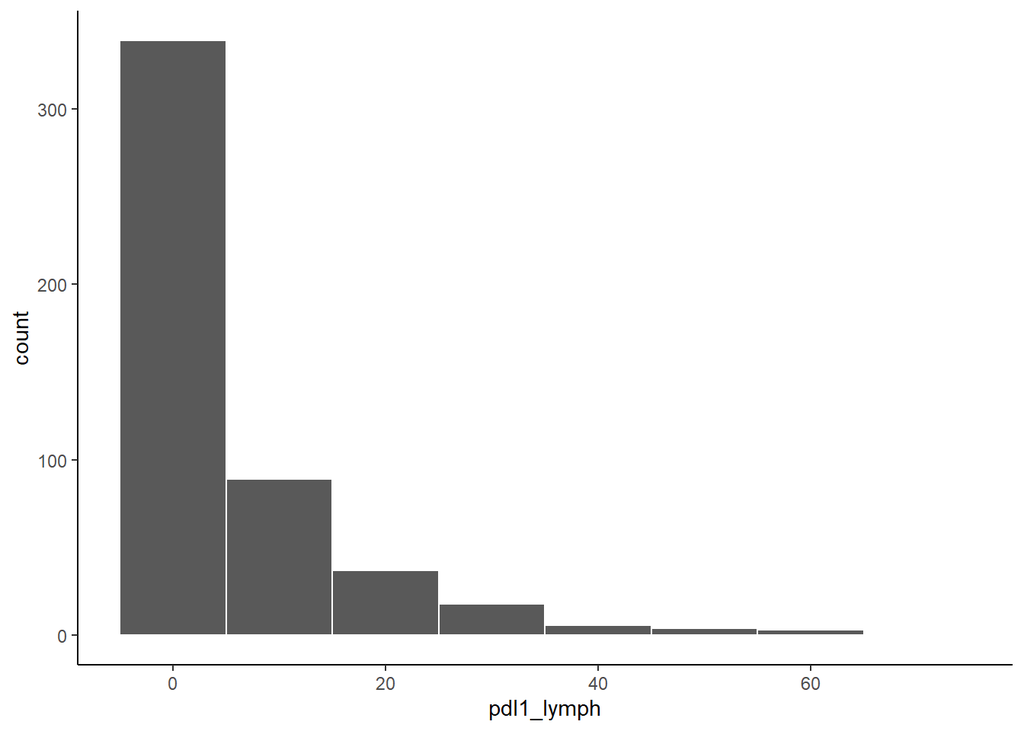

```r
ggplot(df, aes(x = pdl1_lymph)) +
  geom_histogram(binwidth = 10, color = 'white') +
  theme_classic()
```

PD-L1 expression in intratumoral lymphocytes was evaluable in 497 spots. In intratumoral lymphocytes, PD-L1 positivity was observed in a mean of 7 lymphocytes, with a standard deviation of 10 lymphocytes. The median number of positive PD-L1 intratumoral lymphocytes was 5, with an interquartile range of 9 lymphocytes. The minimum and maximum number of positive lymphocytes were 0 and 70, respectively.

### Tumor cells vs intratumoral lymphocytes

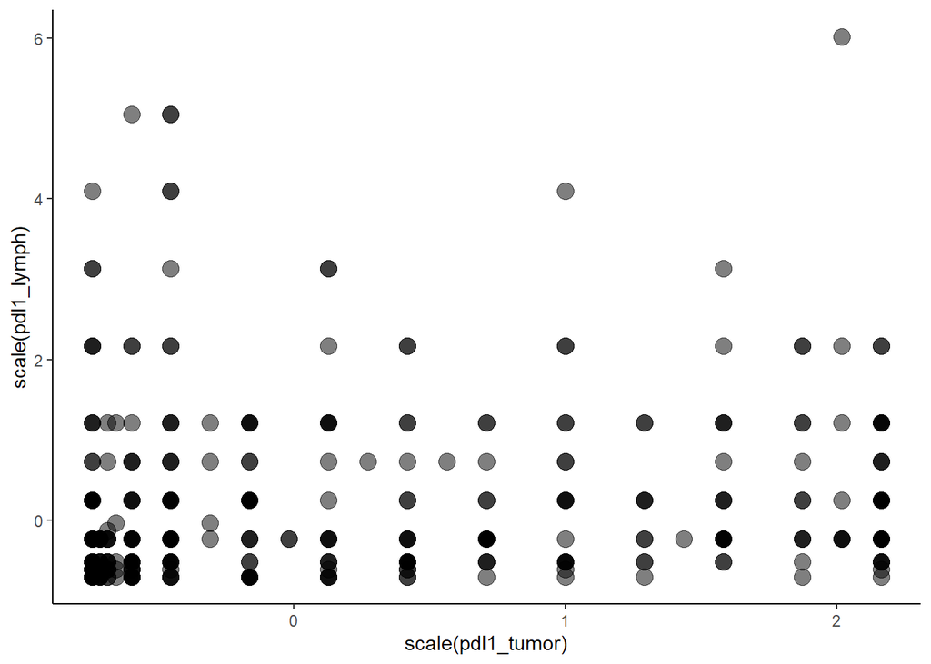

```r
ggplot(df, aes(x = scale(pdl1_tumor), y = scale(pdl1_lymph))) +
  geom_point(size = 4, alpha = 0.5)
```

```r
cor.test(~pdl1_tumor + pdl1_lymph, data = df, method = 'spearman')
```

```
##
##  Spearman's rank correlation rho
##
## data:  pdl1_tumor and pdl1_lymph
## S = 10744154, p-value < 2.2e-16
## alternative hypothesis: true rho is not equal to 0
## sample estimates:
##      rho
## 0.474883
```

A scatterplot of PD-L1 expression in tumor cells vs. intratumoral lymphocytes showed an apparent positive association. This positive association was confirmed using Spearman’s correlation test, which showed a statistically significant, moderate positive correlation ($\rho$=0.47, P<0.0001).

### Expression by pathologic features

```r
df %>%
  group_by(subtype) %>%
  summarize(
    mean = mean(pdl1_tumor, na.rm = TRUE),
    sd = sd(pdl1_tumor, na.rm = TRUE),
    median = median(pdl1_tumor, na.rm = TRUE),
    IQR = IQR(pdl1_tumor, na.rm = TRUE),
    min = min(pdl1_tumor, na.rm = TRUE),
    max = max(pdl1_tumor, na.rm = TRUE)
  )
```

```
## # A tibble: 7 x 7
##   subtype         mean    sd median   IQR   min   max
##   <chr>          <dbl> <dbl>  <dbl> <dbl> <dbl> <dbl>
## 1 Basaloid        31.7 32.1      25    50     0   100
## 2 Papillary        1.2  3.60      0     0     0    20
## 3 Sarcomatoid    100    0       100     0   100   100
## 4 Usual           25.3 34.9       5    50     0   100
## 5 Verrucous        0    0         0     0     0     0
## 6 Warty           14.7 22.8       5    20     0    90
## 7 Warty-Basaloid  37.4 39.2      20    78     0   100
```

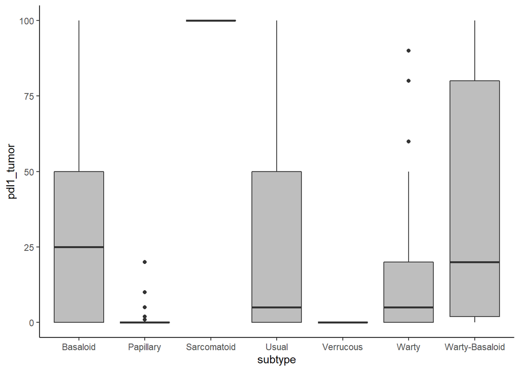

```r
ggplot(df, aes(x = subtype, y = pdl1_tumor)) +
  geom_boxplot(fill = 'grey')
```

```r
kruskal.test(pdl1_tumor ~ subtype, data = df)
```

```
##
##  Kruskal-Wallis rank sum test
##
## data:  pdl1_tumor by subtype
## Kruskal-Wallis chi-squared = 77.257, df = 6, p-value = 1.316e-14
```

When consider percentage of positive cells, higher expression of PD-L1 in tumor cells were noted for the sarcomatoid, basaloid and warty-basaloid subtypes (median of 100%, 25% and 20%, respectively). Low expression levels were noted in the usual and warty subtypes (5%), while the median expression was 0% for the papillary and verrucous subtypes. These differences were statistically significant (P<0.0001).

```r
df %>%
  group_by(subtype) %>%
  summarize(
    mean = mean(pdl1_tumor_h, na.rm = TRUE),
    sd = sd(pdl1_tumor_h, na.rm = TRUE),
    median = median(pdl1_tumor_h, na.rm = TRUE),
    IQR = IQR(pdl1_tumor_h, na.rm = TRUE),
    min = min(pdl1_tumor_h, na.rm = TRUE),
    max = max(pdl1_tumor_h, na.rm = TRUE)
  )
```

```
## # A tibble: 7 x 7
##   subtype          mean    sd median   IQR   min   max
##   <chr>           <dbl> <dbl>  <dbl> <dbl> <dbl> <dbl>
## 1 Basaloid        35.6  39.0    27.5  50       0   150
## 2 Papillary        1.45  4.61    0     0       0    25
## 3 Sarcomatoid    293.   11.5   300    10     280   300
## 4 Usual           37.9  60.5     5    56.2     0   280
## 5 Verrucous        0     0       0     0       0     0
## 6 Warty           15.8  24.7     5    20       0   100
## 7 Warty-Basaloid  54.8  71.3    20    88       0   300
```

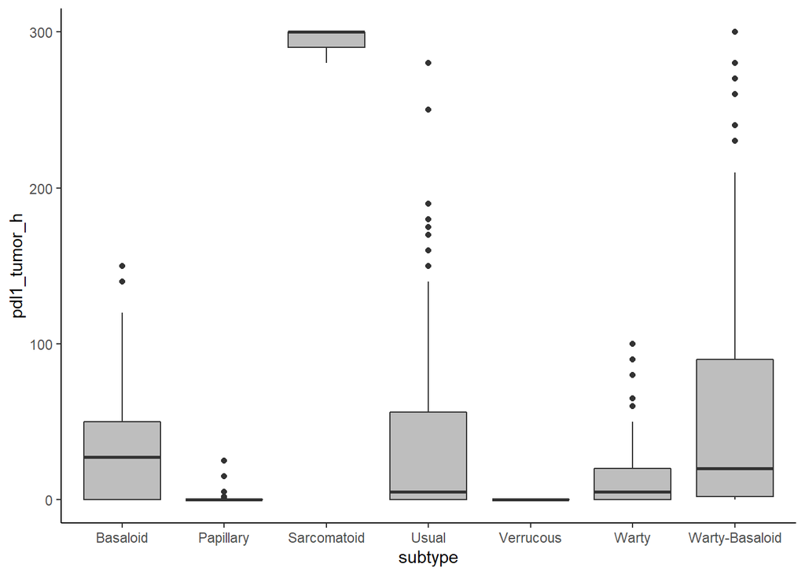

```r
ggplot(df, aes(x = subtype, y = pdl1_tumor_h)) +
  geom_boxplot(fill = 'grey')
```

```r
kruskal.test(pdl1_tumor_h ~ subtype, data = df)
```

```
##
##  Kruskal-Wallis rank sum test
##
## data:  pdl1_tumor_h by subtype
## Kruskal-Wallis chi-squared = 76.236, df = 6, p-value = 2.135e-14
```

The pattern of PD-L1 expression in tumor cells by histologic subtypes when using H-scores was similar to the expression pattern when using percentage of positive tumor cells. Similarly, these differences were statistically significant (P<0.0001).

```r
df %>%
  group_by(subtype) %>%
  summarize(
    mean = mean(pdl1_lymph, na.rm = TRUE),
    sd = sd(pdl1_lymph, na.rm = TRUE),
    median = median(pdl1_lymph, na.rm = TRUE),
    IQR = IQR(pdl1_lymph, na.rm = TRUE),
    min = min(pdl1_lymph, na.rm = TRUE),
    max = max(pdl1_lymph, na.rm = TRUE)
  )
```

```
## # A tibble: 7 x 7
##   subtype          mean     sd median   IQR   min   max
##   <chr>           <dbl>  <dbl>  <dbl> <dbl> <dbl> <dbl>
## 1 Basaloid        9.13  12.2        5   8       0    60
## 2 Papillary       2.78   4.27       2   5       0    20
## 3 Sarcomatoid    18.3   10.4       15  10      10    30
## 4 Usual           8.79  12.0        5   9       0    70
## 5 Verrucous       0.429  0.787      0   0.5     0     2
## 6 Warty           6.48   9.42       5   6       0    40
## 7 Warty-Basaloid  6.42   7.84       5   9       0    50
```

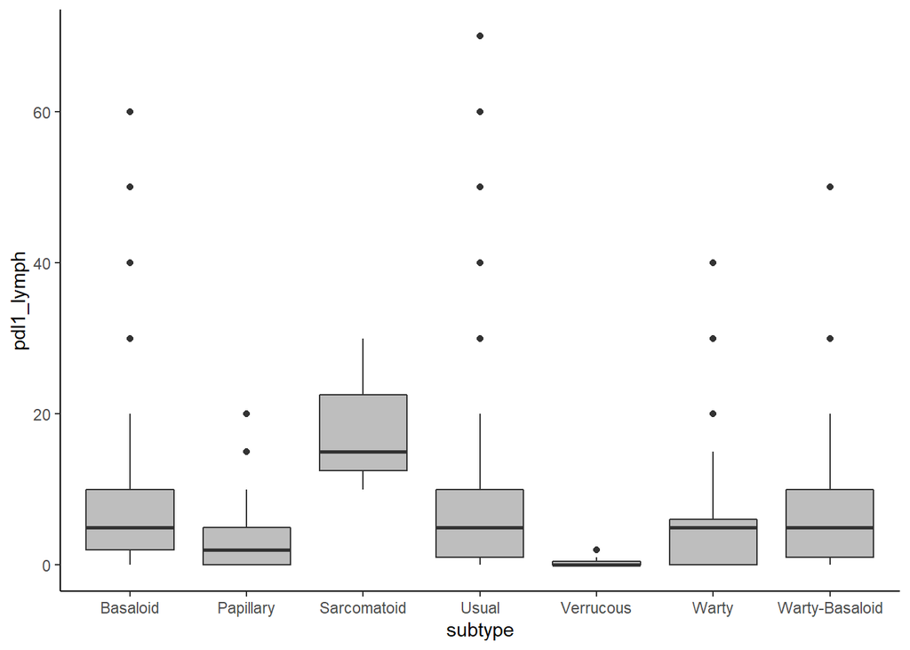

```r
ggplot(df, aes(x = subtype, y = pdl1_lymph)) +
  geom_boxplot(fill = 'grey')
```

```r
kruskal.test(pdl1_lymph ~ subtype, data = df)
```

```
##
##  Kruskal-Wallis rank sum test
##
## data:  pdl1_lymph by subtype
## Kruskal-Wallis chi-squared = 29.76, df = 6, p-value = 4.365e-05
```

```r
library(reticulate)
py_run_string("import os as os")
py_run_string("os.environ['QT_QPA_PLATFORM_PLUGIN_PATH'] = 'C:/Users/Alcides Chaux/anaconda3/Library/plugins/platforms'")
```

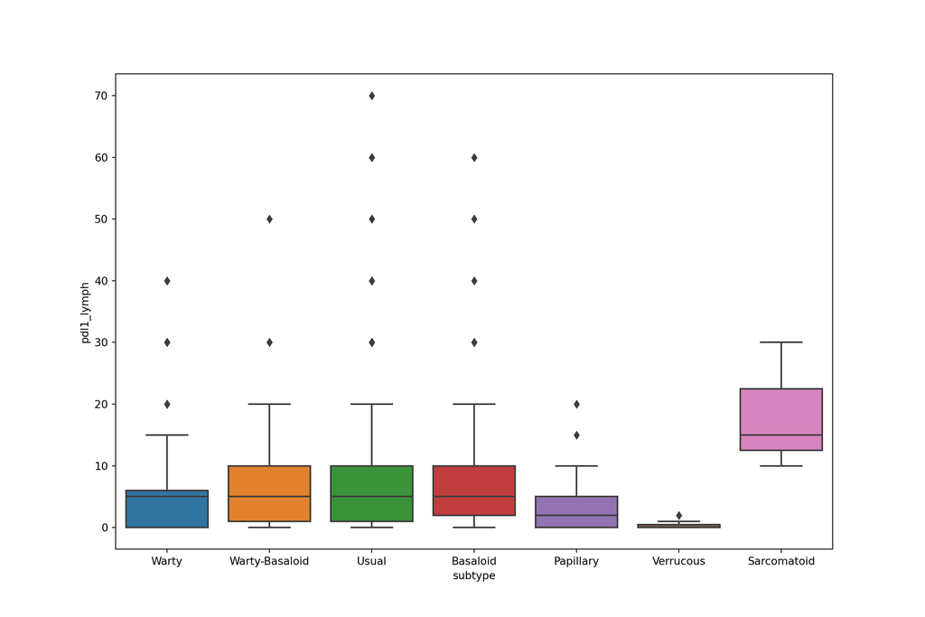

```python
import pandas as pd
data = pd.read_csv('PFCK_PRY_DF.csv')

import matplotlib.pyplot as plt
import seaborn as sns

plt.figure(figsize=[12,8])
sns.boxplot(x = 'subtype', y = 'pdl1_lymph', data = data)
plt.show()
```